# Bank Telemarketing

Oleh Bohoslavets

9/5/2020

# A data-driven approach to predict the success of bank telemarketing

### Input variables:

#### Bank client data:

1 - age (numeric)

2 - job : type of job (categorical: “admin.”,“blue-collar”,“entrepreneur”,“housemaid”,“management”,“retired”,“self-employed”,“services”,“student”,“technician”,“unemployed”,“unknown”)

3 - marital : marital status (categorical: “divorced”,“married”,“single”,“unknown”; note: “divorced” means divorced or widowed)

4 - education (categorical: “basic.4y”,“basic.6y”,“basic.9y”,“high.school”,“illiterate”,“professional.course”,“university.degree”,“unknown”)

5 - default: has credit in default? (categorical: “no”,“yes”,“unknown”)

6 - housing: has housing loan? (categorical: “no”,“yes”,“unknown”)

7 - loan: has personal loan? (categorical: “no”,“yes”,“unknown”)

#### Related with the last contact of the current campaign:

8 - contact: contact communication type (categorical: “cellular”,“telephone”)

9 - month: last contact month of year (categorical: “jan”, “feb”, “mar”, …, “nov”, “dec”)

10 - day_of_week: last contact day of the week (categorical: “mon”,“tue”,“wed”,“thu”,“fri”)

11 - duration: last contact duration, in seconds (numeric). Important note: this attribute highly affects the output target (e.g., if duration=0 then y=“no”). Yet, the duration is not known before a call is performed. Also, after the end of the call y is obviously known. Thus, this input should only be included for benchmark purposes and should be discarded if the intention is to have a realistic predictive model.

#### Other attributes:

12 - campaign: number of contacts performed during this campaign and for this client (numeric, includes last contact)

13 - pdays: number of days that passed by after the client was last contacted from a previous campaign (numeric; 999 means client was not previously contacted)

14 - previous: number of contacts performed before this campaign and for this client (numeric)

15 - poutcome: outcome of the previous marketing campaign (categorical: “failure”,“nonexistent”,“success”)

#### Social and economic context attributes

16 - emp.var.rate: employment variation rate - quarterly indicator (numeric)

17 - cons.price.idx: consumer price index - monthly indicator (numeric)

18 - cons.conf.idx: consumer confidence index - monthly indicator (numeric)

19 - euribor3m: euribor 3 month rate - daily indicator (numeric)

20 - nr.employed: number of employees - quarterly indicator (numeric)

### Output variable (desired target):

21 - y - has the client subscribed a term deposit? (binary: “yes”,“no”)

### Missing Attribute Values:

There are several missing values in some categorical attributes, all coded with the “unknown” label. These missing values can be treated as a possible class label or using deletion or imputation techniques.

### Data Visualization

Dimensions of the dataset: 4119 rows and 21 columns.

```r
## Variable summary:
str(data)
```

```
## 'data.frame':    4119 obs. of  21 variables:
##  $ age           : int  30 39 25 38 47 32 32 41 31 35 ...
##  $ job           : Factor w/ 12 levels "admin.","blue-collar",..: 2 8 8 8 1 8 1 3 8 2 ...
##  $ marital       : Factor w/ 4 levels "divorced","married",..: 2 3 2 2 2 3 3 2 1 2 ...
##  $ education     : Factor w/ 8 levels "basic.4y","basic.6y",..: 3 4 4 3 7 7 7 7 6 3 ...
##  $ default       : Factor w/ 3 levels "no","unknown",..: 1 1 1 1 1 1 1 2 1 2 ...
##  $ housing       : Factor w/ 3 levels "no","unknown",..: 3 1 3 2 3 1 3 3 1 1 ...
##  $ loan          : Factor w/ 3 levels "no","unknown",..: 1 1 1 2 1 1 1 1 1 1 ...
##  $ contact       : Factor w/ 2 levels "cellular","telephone": 1 2 2 2 1 1 1 1 1 2 ...
##  $ month         : Factor w/ 10 levels "apr","aug","dec",..: 7 7 5 5 8 10 10 8 8 7 ...
##  $ day_of_week   : Factor w/ 5 levels "fri","mon","thu",..: 1 1 5 1 2 3 2 2 4 3 ...
##  $ duration      : int  487 346 227 17 58 128 290 44 68 170 ...
##  $ campaign      : int  2 4 1 3 1 3 4 2 1 1 ...
##  $ pdays         : int  999 999 999 999 999 999 999 999 999 999 ...
##  $ previous      : int  0 0 0 0 0 2 0 0 1 0 ...
##  $ poutcome      : Factor w/ 3 levels "failure","nonexistent",..: 2 2 2 2 2 1 2 2 1 2 ...
##  $ emp.var.rate  : num  -1.8 1.1 1.4 1.4 -0.1 -1.1 -1.1 -0.1 -0.1 1.1 ...
##  $ cons.price.idx: num  92.9 94 94.5 94.5 93.2 ...
##  $ cons.conf.idx : num  -46.2 -36.4 -41.8 -41.8 -42 -37.5 -37.5 -42 -42 -36.4 ...
##  $ euribor3m     : num  1.31 4.86 4.96 4.96 4.19 ...
##  $ nr.employed   : num  5099 5191 5228 5228 5196 ...
##  $ y             : Factor w/ 2 levels "yes","no": 2 2 2 2 2 2 2 2 2 2 ...
```

```r
## Let's glance at the top of the table:
kable(head(data))
```

| age | job | marital | education | default | housing | loan | contact | month | day_of_week | duration | campaign | pdays | previous | poutcome | emp.var.rate | cons.price.idx | cons.conf.idx | euribor3m | nr.employed | y |
| --- | --- | --- | --- | --- | --- | --- | --- | --- | --- | --- | --- | --- | --- | --- | --- | --- | --- | --- | --- | --- |
| 30 | blue-collar | married | basic.9y | no | yes | no | cellular | may | fri | 487 | 2 | 999 | 0 | nonexistent | -1.8 | 92.893 | -46.2 | 1.313 | 5099.1 | no |
| 39 | services | single | high.school | no | no | no | telephone | may | fri | 346 | 4 | 999 | 0 | nonexistent | 1.1 | 93.994 | -36.4 | 4.855 | 5191.0 | no |
| 25 | services | married | high.school | no | yes | no | telephone | jun | wed | 227 | 1 | 999 | 0 | nonexistent | 1.4 | 94.465 | -41.8 | 4.962 | 5228.1 | no |
| 38 | services | married | basic.9y | no | unknown | unknown | telephone | jun | fri | 17 | 3 | 999 | 0 | nonexistent | 1.4 | 94.465 | -41.8 | 4.959 | 5228.1 | no |
| 47 | admin. | married | university.degree | no | yes | no | cellular | nov | mon | 58 | 1 | 999 | 0 | nonexistent | -0.1 | 93.200 | -42.0 | 4.191 | 5195.8 | no |
| 32 | services | single | university.degree | no | no | no | cellular | sep | thu | 128 | 3 | 999 | 2 | failure | -1.1 | 94.199 | -37.5 | 0.884 | 4963.6 | no |

```r
## Summary of the variables:
summary(data)
```

```
##       age                 job           marital                   education
##  Min.   :18.00   admin.     :1012   divorced: 446   university.degree  :1264
##  1st Qu.:32.00   blue-collar: 884   married :2509   high.school        : 921
##  Median :38.00   technician : 691   single  :1153   basic.9y           : 574
##  Mean   :40.11   services   : 393   unknown :  11   professional.course: 535
##  3rd Qu.:47.00   management : 324                   basic.4y           : 429
##  Max.   :88.00   retired    : 166                   basic.6y           : 228
##                  (Other)    : 649                   (Other)            : 168
##     default        housing          loan           contact         month
##  no     :3315   no     :1839   no     :3349   cellular :2652   may    :1378
##  unknown: 803   unknown: 105   unknown: 105   telephone:1467   jul    : 711
##  yes    :   1   yes    :2175   yes    : 665                    aug    : 636
##                                                                jun    : 530
##                                                                nov    : 446
##                                                                apr    : 215
##                                                                (Other): 203
##  day_of_week    duration         campaign          pdays          previous
##  fri:768     Min.   :   0.0   Min.   : 1.000   Min.   :  0.0   Min.   :0.0000
##  mon:855     1st Qu.: 103.0   1st Qu.: 1.000   1st Qu.:999.0   1st Qu.:0.0000
##  thu:860     Median : 181.0   Median : 2.000   Median :999.0   Median :0.0000
##  tue:841     Mean   : 256.8   Mean   : 2.537   Mean   :960.4   Mean   :0.1903
##  wed:795     3rd Qu.: 317.0   3rd Qu.: 3.000   3rd Qu.:999.0   3rd Qu.:0.0000
##              Max.   :3643.0   Max.   :35.000   Max.   :999.0   Max.   :6.0000
##
##         poutcome     emp.var.rate      cons.price.idx  cons.conf.idx
##  failure    : 454   Min.   :-3.40000   Min.   :92.20   Min.   :-50.8
##  nonexistent:3523   1st Qu.:-1.80000   1st Qu.:93.08   1st Qu.:-42.7
##  success    : 142   Median : 1.10000   Median :93.75   Median :-41.8
##                     Mean   : 0.08497   Mean   :93.58   Mean   :-40.5
##                     3rd Qu.: 1.40000   3rd Qu.:93.99   3rd Qu.:-36.4
##                     Max.   : 1.40000   Max.   :94.77   Max.   :-26.9
##
##    euribor3m      nr.employed     y
##  Min.   :0.635   Min.   :4964   yes: 451
##  1st Qu.:1.334   1st Qu.:5099   no :3668
##  Median :4.857   Median :5191
##  Mean   :3.621   Mean   :5166
##  3rd Qu.:4.961   3rd Qu.:5228
##  Max.   :5.045   Max.   :5228
##
```

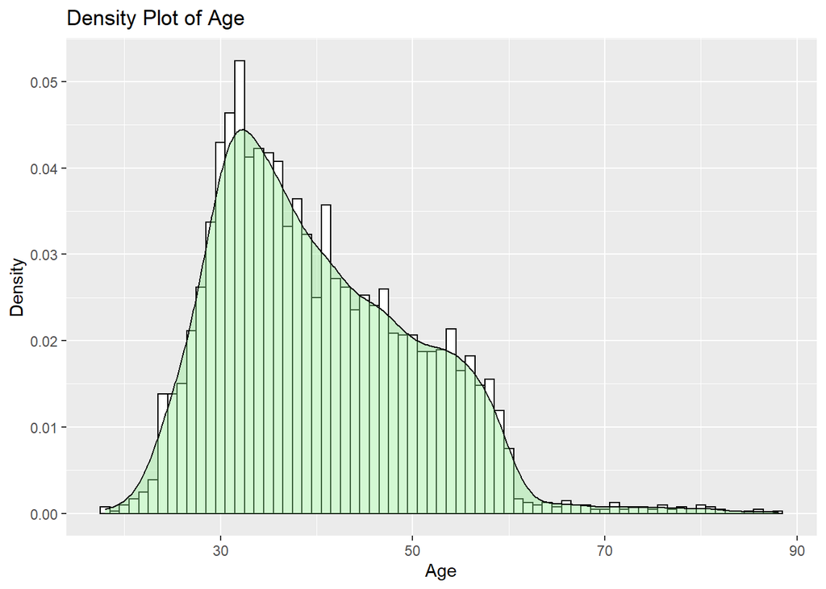

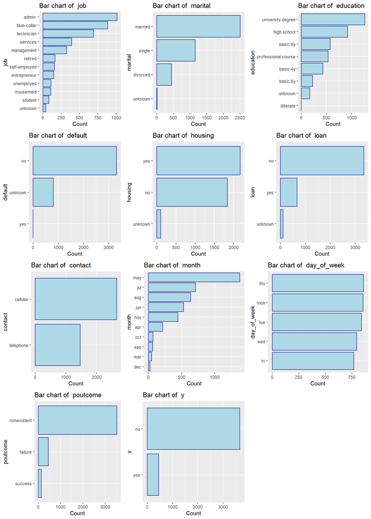

Barcharts show the distributions of customers in each category. Bar chart of y (response variable) shows that the data is imbalanced, we will have to take this into account when building models and evaluating their performance

There are several missing values in some categorical attributes, all coded with the “unknown” label. These missing values will be treated as a class label.

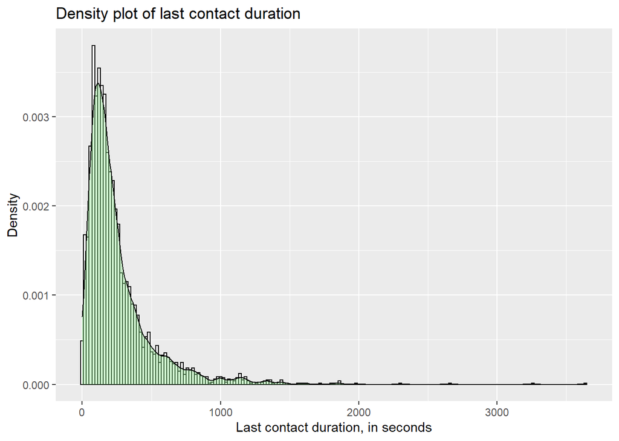

Important note: this attribute highly affects the output target (e.g., if duration=0 then y=‘no’). Yet, the duration is not known before a call is performed. Also, after the end of the call y is obviously known. Thus, this input should only be included for benchmark purposes and should be discarded if the intention is to have a realistic predictive model.

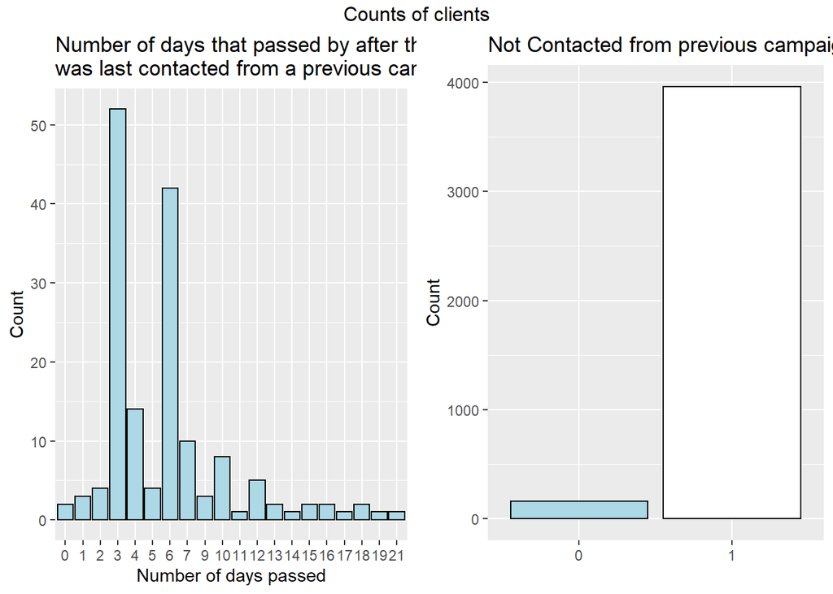

[figure not shown]

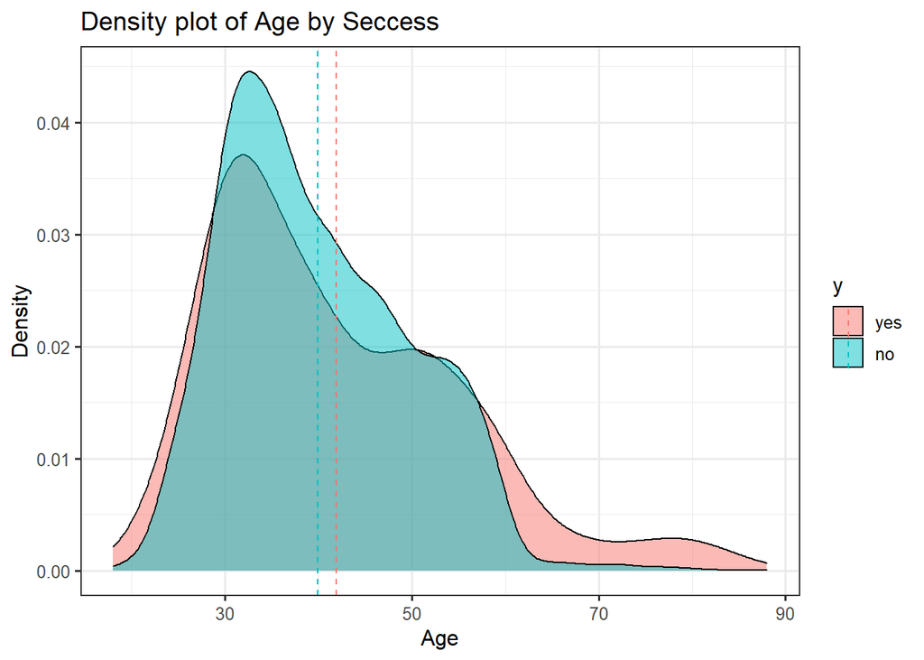

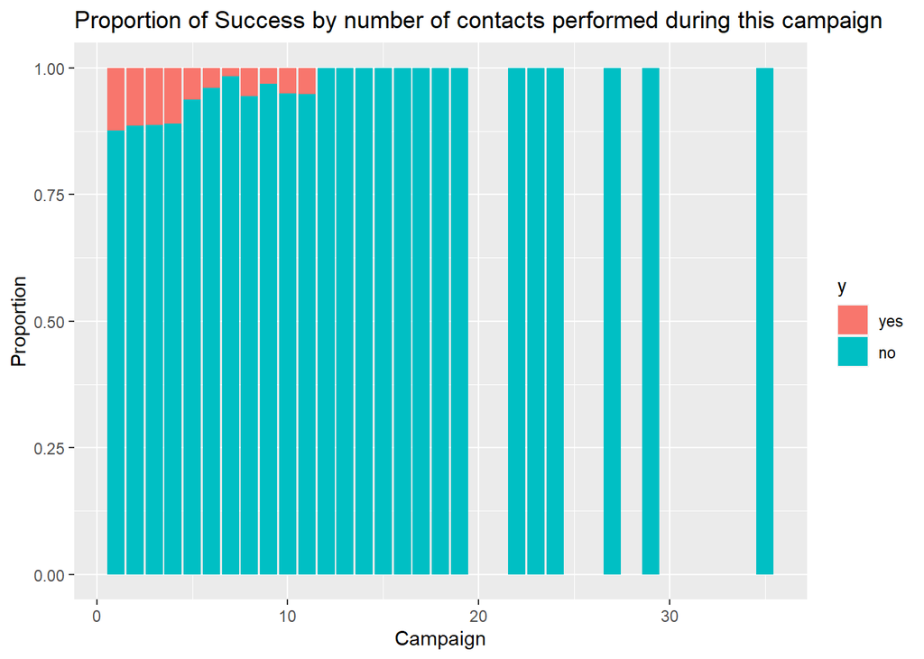

Proportions plot of success by campaign shows that the chance of a person subscribing to term deposit after 12 phone calls is close to 0. There is no need to call people more than that and there are more efficient ways to allocate time of calling employees.

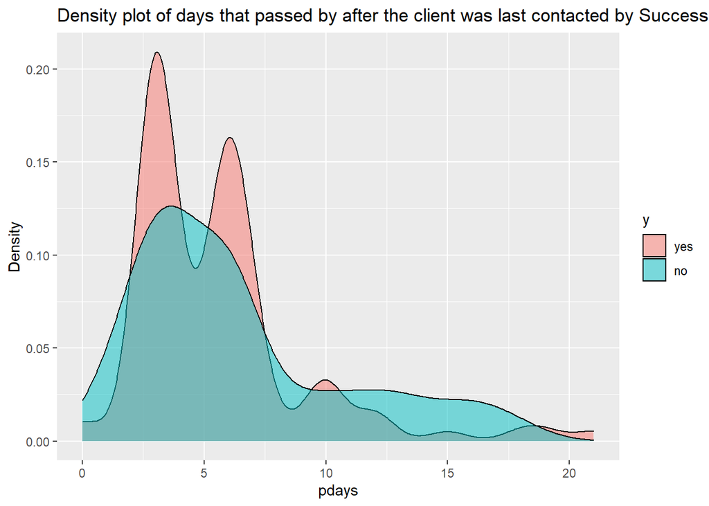

3 to 7 days that passed by after the client was last contacted from a previous campaign is the optimal time for a successful call

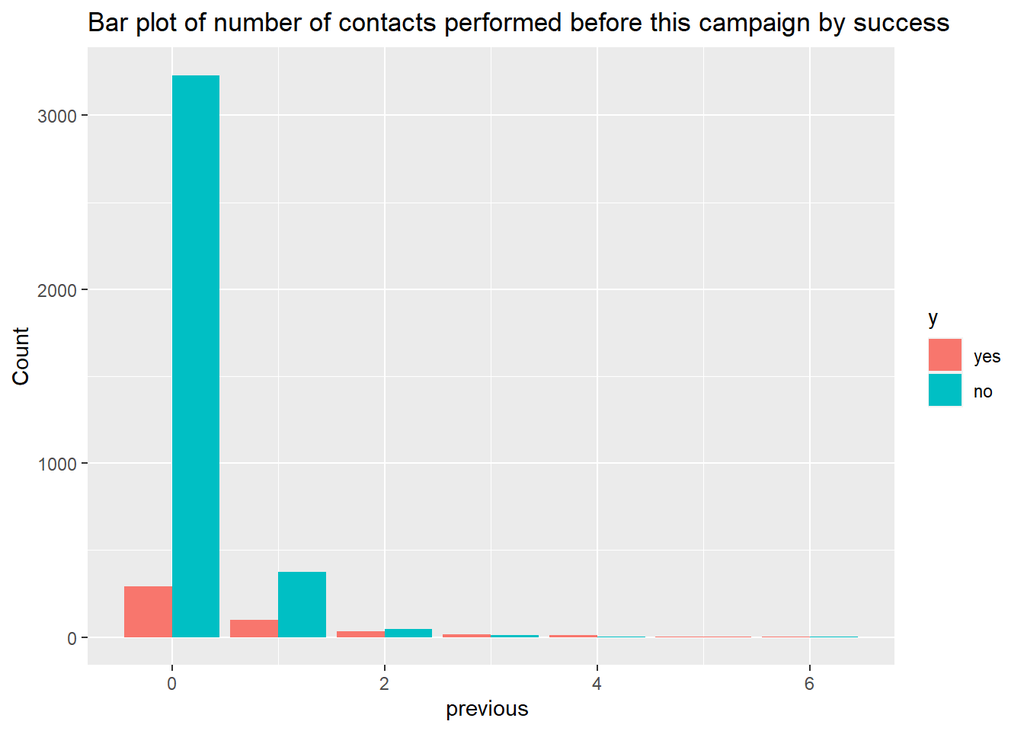

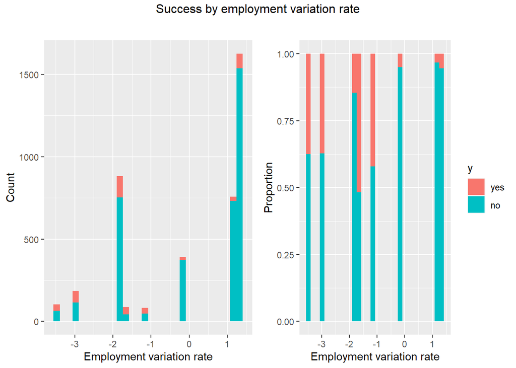

It appears that we have the higher rate of success when the Employment variation rate is negative

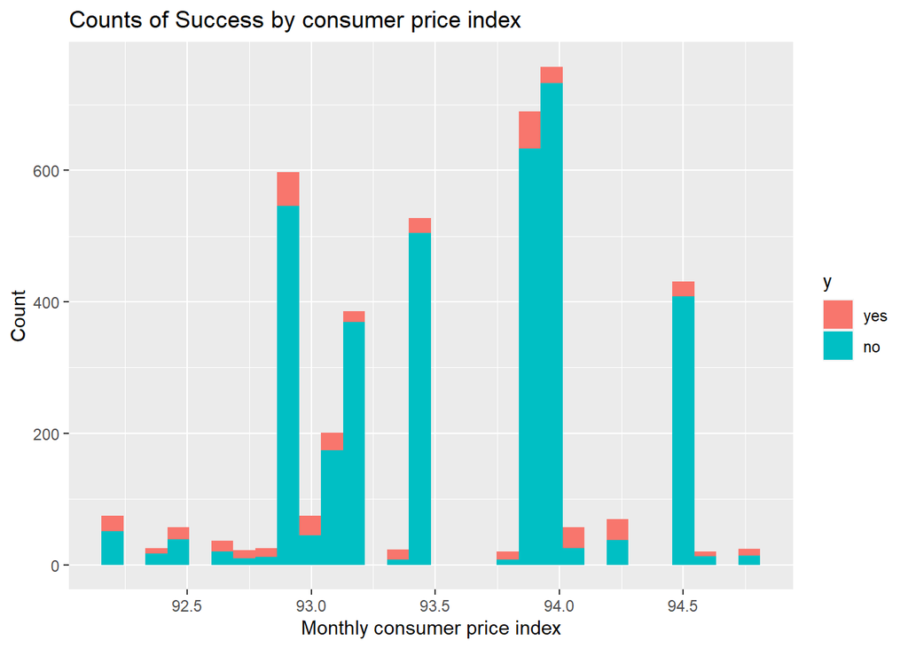

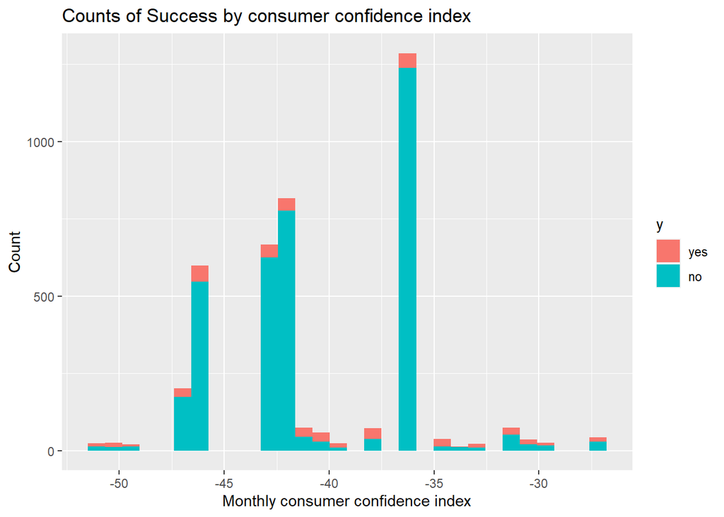

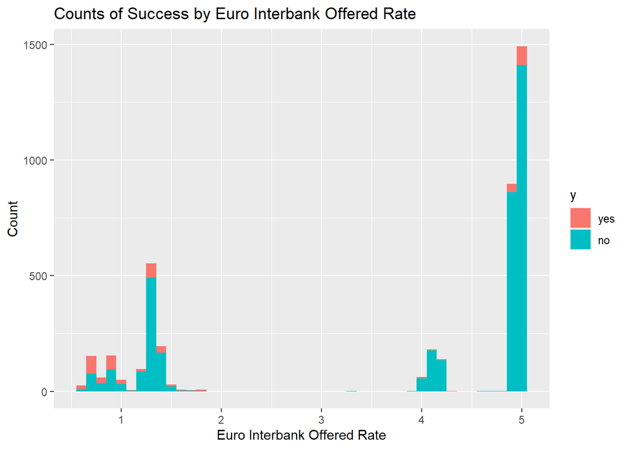

The lower the Euro Interbank Offered Rate the higher chance of success Which is intuitive because low interest rates mean more spending money in consumers’ pockets

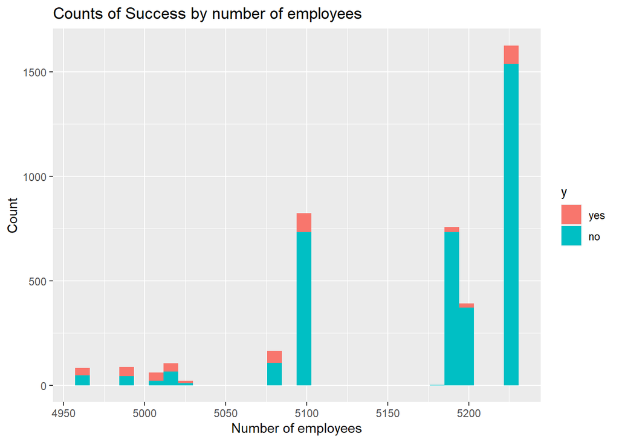

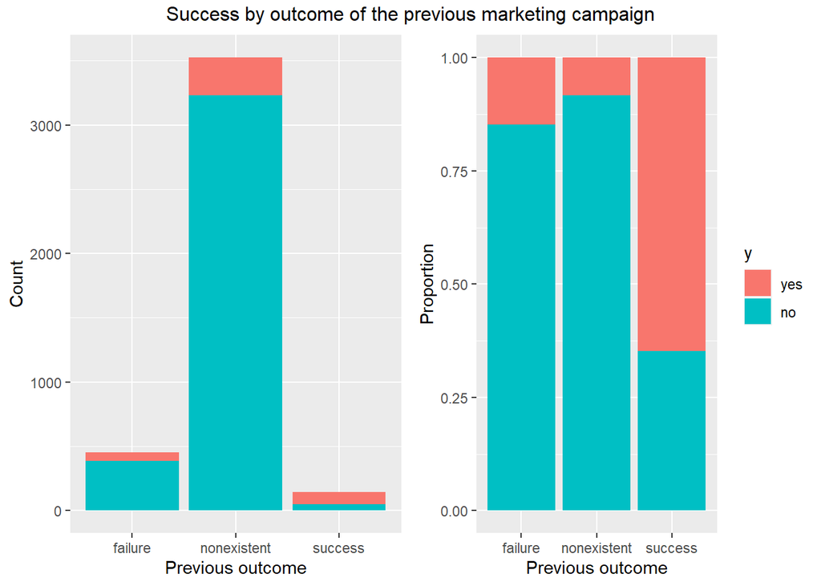

### 2. Data Preparation

```r
effect <- dummyVars(~ job + marital + education + default + housing + loan + month + day_of_week + poutcome, data = data)
dummies <- as.data.frame(predict(effect, data))
data <- bind_cols(data, dummies)
exclude <- names(data) %in% c("job","duration","marital","education","default","housing",
                              "loan","contact","month","day_of_week","poutcome","job.admin.",
                              "marital.divorced","education.basic.4y","default.no","housing.no",
                              "loan.no","month.apr","day_of_week.fri","poutcome.failure")
```

Exclude duration because this attribute highly affects the output target (e.g., if duration=0 then y=“no”). Yet, the duration is not known before a call is performed. Also, after the end of the call y is obviously known. Thus, this input should only be included for benchmark purposes and should be discarded if the intention is to have a realistic predictive model.

```r
data <- data[,!exclude]
str(data)
```

```
## 'data.frame':    4119 obs. of  52 variables:
##  $ age                          : int  30 39 25 38 47 32 32 41 31 35 ...
##  $ campaign                     : int  2 4 1 3 1 3 4 2 1 1 ...
##  $ pdays                        : int  999 999 999 999 999 999 999 999 999 999 ...
##  $ previous                     : int  0 0 0 0 0 2 0 0 1 0 ...
##  $ emp.var.rate                 : num  -1.8 1.1 1.4 1.4 -0.1 -1.1 -1.1 -0.1 -0.1 1.1 ...
##  $ cons.price.idx               : num  92.9 94 94.5 94.5 93.2 ...
##  $ cons.conf.idx                : num  -46.2 -36.4 -41.8 -41.8 -42 -37.5 -37.5 -42 -42 -36.4 ...
##  $ euribor3m                    : num  1.31 4.86 4.96 4.96 4.19 ...
##  $ nr.employed                  : num  5099 5191 5228 5228 5196 ...
##  $ y                            : Factor w/ 2 levels "yes","no": 2 2 2 2 2 2 2 2 2 2 ...
##  $ job.blue-collar              : num  1 0 0 0 0 0 0 0 0 1 ...
##  $ job.entrepreneur             : num  0 0 0 0 0 0 0 1 0 0 ...
##  $ job.housemaid                : num  0 0 0 0 0 0 0 0 0 0 ...
##  $ job.management               : num  0 0 0 0 0 0 0 0 0 0 ...
```

[output cut: 38 more lines]

Correlation matrix of all variables that are going to be used for the model building

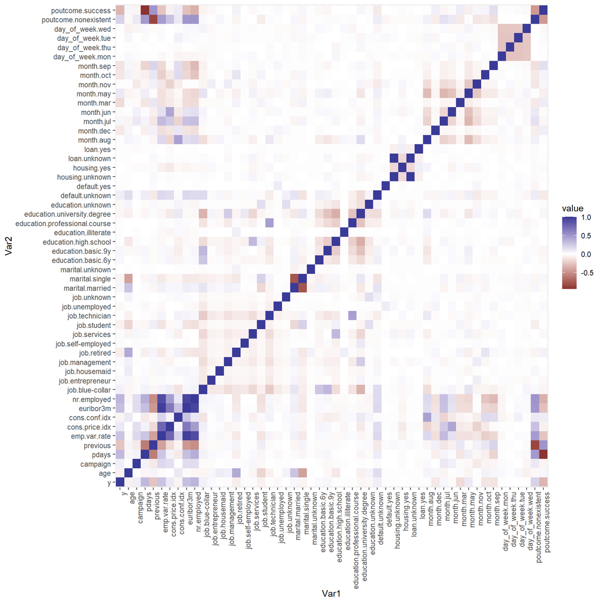

Split data into training and test set

```r
set.seed(1234)
trainIndex <- createDataPartition(data$y, p = .8,
                                  list = FALSE,
                                  times = 1)

dataTrain <- data[ trainIndex,]
dataTest  <- data[-trainIndex,]
```

### 3. Model Building and Evaluation

In our case the data is very imbalanced, predicting correctly that the client subscribed a term deposit is a lot more important than correctly prdeicting that they did not subscrib a term deposit This means that in our case the overall accuracy is not a good measurefor evaluating the classifier

We will do 10 fold cross-validation

Because the data is very imbalanced, when running Caret we must select ‘prSummary’ summaryFunction to calculate the area under precision-recall curve for each test data, this is used to select the best model from searching across all parameters

```r
ctrl <- trainControl(method="cv", summaryFunction=prSummary, classProbs=T,
                     savePredictions = T,
                     verboseIter = F)
```

```
## Boosted Logistic Regression
##
## 3296 samples
##   51 predictor
##    2 classes: 'yes', 'no'
##
## No pre-processing
## Resampling: Cross-Validated (10 fold)
## Summary of sample sizes: 2967, 2966, 2965, 2967, 2967, 2966, ...
## Resampling results across tuning parameters:
##
##   nIter  AUC        Precision  Recall     F
##   11     0.3863301  0.6500023  0.2243243  0.3253559
##   21     0.4025408  0.6322719  0.2078829  0.3105595
##   31     0.4110552  0.6804505  0.2159159  0.3215306
##
## AUC was used to select the optimal model using the largest value.
## The final value used for the model was nIter = 31.
```

```
## k-Nearest Neighbors
##
## 3296 samples
##   51 predictor
##    2 classes: 'yes', 'no'
##
## No pre-processing
## Resampling: Cross-Validated (10 fold)
## Summary of sample sizes: 2967, 2966, 2967, 2967, 2965, 2967, ...
## Resampling results across tuning parameters:
##
##   k  AUC        Precision  Recall     F
##   5  0.3298147  0.4920073  0.2436937  0.3208425
##   7  0.3594920  0.5318704  0.2464715  0.3293639
##   9  0.3816701  0.5724568  0.2521021  0.3438065
##
## AUC was used to select the optimal model using the largest value.
## The final value used for the model was k = 9.
```

```
## Random Forest
##
## 3296 samples
##   51 predictor
##    2 classes: 'yes', 'no'
##
## No pre-processing
## Resampling: Cross-Validated (10 fold)
## Summary of sample sizes: 2966, 2966, 2967, 2966, 2967, 2967, ...
## Resampling results across tuning parameters:
##
##   mtry  AUC        Precision  Recall     F
##    2    0.4174408  0.7400583  0.1522523  0.2453062
##   26    0.3728375  0.4856420  0.2295796  0.3041057
##   51    0.3644666  0.4597417  0.2379129  0.3080097
##
## AUC was used to select the optimal model using the largest value.
## The final value used for the model was mtry = 2.
```

```
## Neural Network
##
## 3296 samples
##   51 predictor
##    2 classes: 'yes', 'no'
##
## No pre-processing
## Resampling: Cross-Validated (10 fold)
## Summary of sample sizes: 2966, 2967, 2967, 2967, 2966, 2966, ...
## Resampling results across tuning parameters:
##
##   size  decay  AUC         Precision  Recall       F
##   1     0e+00  0.03251520  0.6000000  0.008333333  0.1463415
##   1     1e-04  0.00000000        NaN  0.000000000        NaN
##   1     1e-01  0.42604989  0.5989692  0.263213213  0.3505397
##   3     0e+00  0.00000000        NaN  0.000000000        NaN
##   3     1e-04  0.05109290  0.5250000  0.038888889  0.2830882
##   3     1e-01  0.37687654  0.6105794  0.240540541  0.3297760
##   5     0e+00  0.08712785  0.6683007  0.075000000  0.3618973
##   5     1e-04  0.05672687  0.6869748  0.057507508  0.4043655
##   5     1e-01  0.38689219  0.6120015  0.207357357  0.2997403
##
## AUC was used to select the optimal model using the largest value.
## The final values used for the model were size = 1 and decay = 0.1.
```

```
## Stochastic Gradient Boosting
##
## 3296 samples
##   51 predictor
##    2 classes: 'yes', 'no'
##
## No pre-processing
## Resampling: Cross-Validated (10 fold)
## Summary of sample sizes: 2966, 2967, 2967, 2965, 2967, 2966, ...
## Resampling results across tuning parameters:
##
##   interaction.depth  n.trees  AUC        Precision  Recall     F
##   1                   50      0.4410424  0.6285415  0.2241742  0.3293802
##   1                  100      0.4391529  0.6445072  0.2242492  0.3319417
##   1                  150      0.4336387  0.6184374  0.2298048  0.3342674
##   2                   50      0.4345178  0.6142189  0.2242492  0.3266212
##   2                  100      0.4240138  0.5712201  0.2381381  0.3358256
##   2                  150      0.4234561  0.5964203  0.2436186  0.3448563
##   3                   50      0.4217543  0.5972665  0.2353604  0.3361629
##   3                  100      0.4212287  0.5741667  0.2325075  0.3298308
##   3                  150      0.4185020  0.5637534  0.2487988  0.3425641
##
## Tuning parameter 'shrinkage' was held constant at a value of 0.1
##
## Tuning parameter 'n.minobsinnode' was held constant at a value of 10
## AUC was used to select the optimal model using the largest value.
## The final values used for the model were n.trees = 50, interaction.depth =
##  1, shrinkage = 0.1 and n.minobsinnode = 10.
```

Running on Caret train output: single group, imbalanced data Very imbalanced data requires special consideration where we are interested just in the positive class. In these situations the ROC gives a overly optimistic picture of the situation because it does not directly consider false positives in the positive fraction. So we can use the precision-recall curve or the precision-recall gain curve, and the area under these as metrics. These work in the same way as a ROC, but precision vs recall is plotted while we change the probability required for a positive parameter.

```r
res <- evalm(list(fit1,fit2,fit3,fit4,fit5),gnames=c("LogitBoost","knn","rf","nnet","gbm"), silent = TRUE)
```

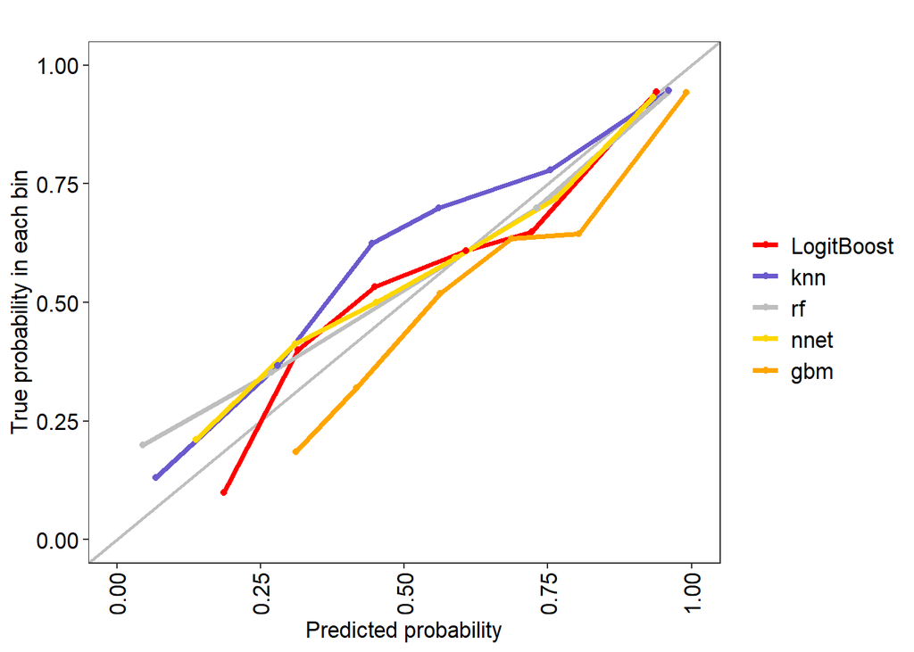

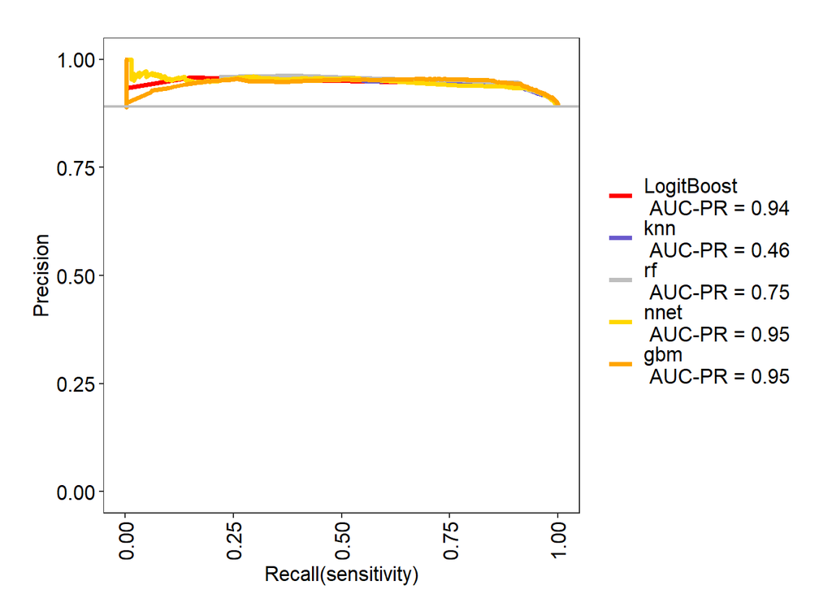

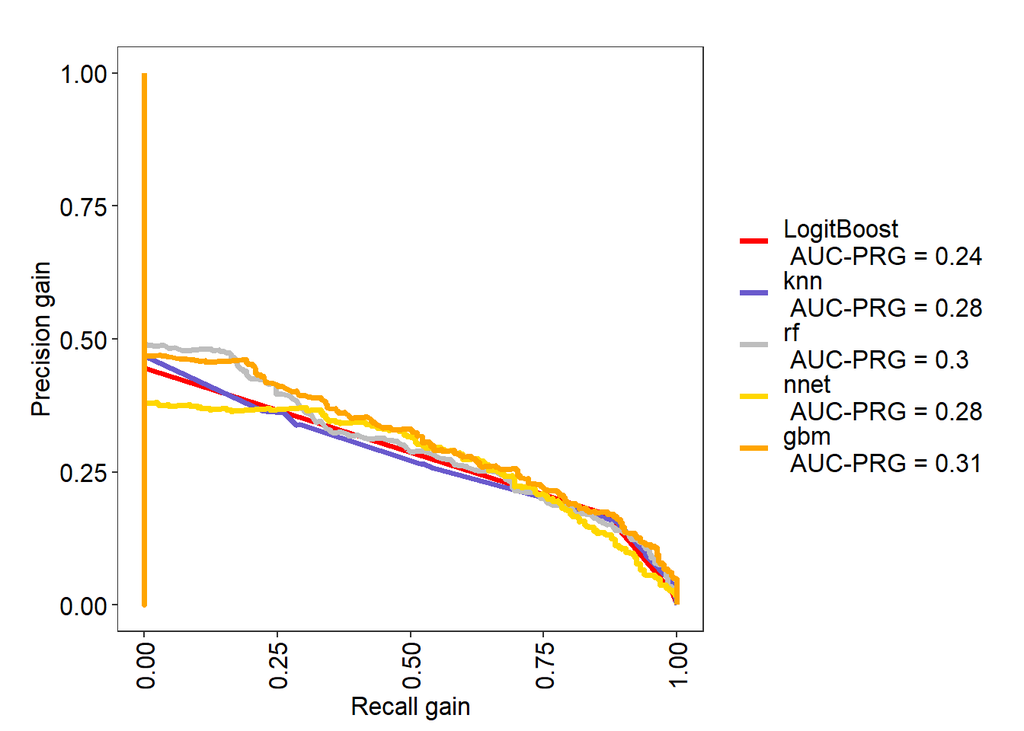

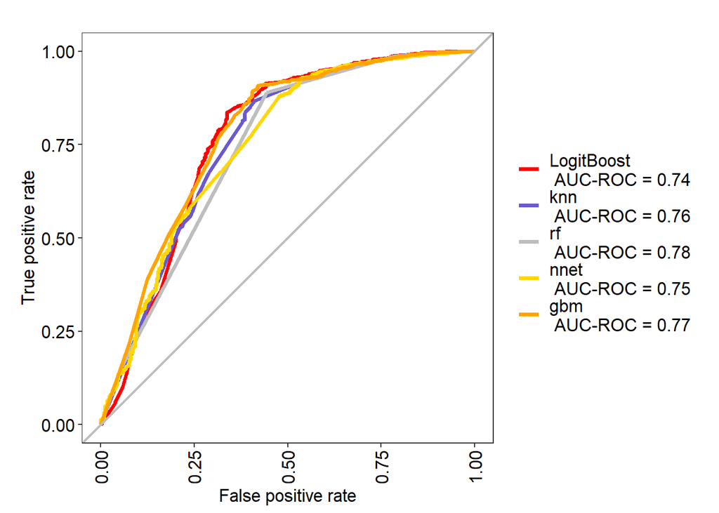

Since our data is highly imbalances in our case we need to evaluate AUC-PR, AUC-PRG coeficients Based on AUC-PRG the best performing models are rf and gbm Based on AUC-PR the best performing models are LogitBoost, NNet and gbm

Now lets predict class membership using cutoff 0.50 (we could change the model’s cutoff based on clients requirements when we build models)

```r
finalfit <- predict(fit5, dataTest)
dataTest <- bind_cols(dataTest, finalfit)
dataTest <- rename(dataTest, Prediction = ...53)
confusionMatrix(dataTest$Prediction, dataTest$y)
```

```
## Confusion Matrix and Statistics
##
##           Reference
## Prediction yes  no
##        yes  18  11
##        no   72 722
##
##                Accuracy : 0.8991
##                  95% CI : (0.8765, 0.9189)
##     No Information Rate : 0.8906
##     P-Value [Acc > NIR] : 0.236
##
##                   Kappa : 0.2633
##
##  Mcnemar's Test P-Value : 4.523e-11
##
##             Sensitivity : 0.20000
##             Specificity : 0.98499
##          Pos Pred Value : 0.62069
##          Neg Pred Value : 0.90932
##              Prevalence : 0.10936
##          Detection Rate : 0.02187
##    Detection Prevalence : 0.03524
##       Balanced Accuracy : 0.59250
##
##        'Positive' Class : yes
##
```

We now turn to predictive goal of detecting, among a set of new records, the ones most likely to belong to a class of interest. Note:This differs from a goal of predicting class membership for each record

Let’s build the lift curve for our models and determine how effectively we can “skim the cream” by selecting relatively small number of cases and getting a relatively large portion of the subscribers

```r
results <- data.frame(y = dataTest$y)
results$LogitBoost <- predict(fit1, dataTest, type = "prob")[,"yes"]
results$knn <- predict(fit2, dataTest, type = "prob")[,"yes"]
results$rf <- predict(fit3, dataTest, type = "prob")[,"yes"]
results$nnet <- predict(fit4, dataTest, type = "prob")[,"yes"]
results$gbm <- predict(fit5, dataTest, type = "prob")[,"yes"]
head(results)
```

```
##     y  LogitBoost       knn    rf       nnet        gbm
## 1  no 0.047425873 0.1111111 0.002 0.05612529 0.05373112
## 2  no 0.047425873 0.1111111 0.002 0.07878160 0.05373112
## 3 yes 0.047425873 0.2222222 0.006 0.07889584 0.05373112
## 4  no 0.006692851 0.0000000 0.008 0.04452198 0.05373112
## 5  no 0.047425873 0.0000000 0.006 0.03424306 0.05373112
## 6  no 0.047425873 0.2222222 0.004 0.08724035 0.07700295
```

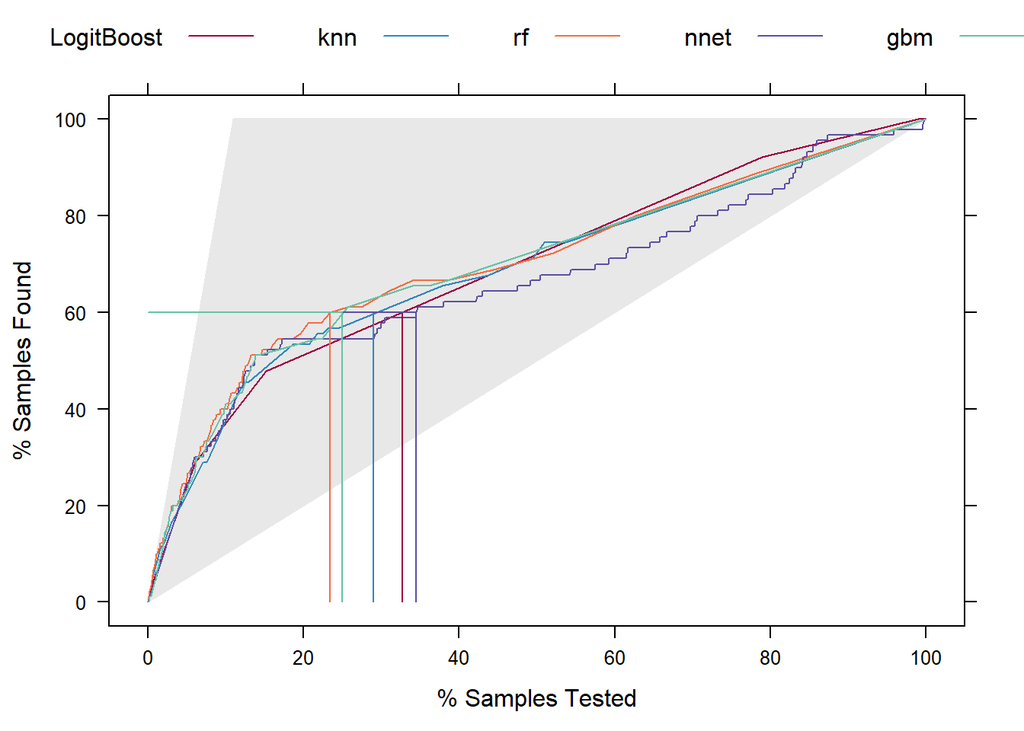

```r
trellis.par.set(caretTheme())
lift_obj <- lift(y ~ LogitBoost + knn + rf + nnet + gbm, data = results)
plot(lift_obj, values = 60, auto.key = list(columns = 5,
                                            lines = TRUE,
                                            points = FALSE))
```